# Лабораторная работа № 3

Настройка прав доступа

Жукова С. В. НПИбд-01-24

Российский университет дружбы народов, Москва, Россия

19 сентября 2025

## Докладчик

- Жукова София Викторовна
- студентка
- направления прикладной информатика
- Российский университет дружбы народов
- 1032240966@pfur.ru
- https://svzhukova.github.io/ru/

# Вводная часть

Лабораторная работа Настройка прав доступа

## Цель

Целью данной работы является получение навыков настройки базовых и специальных прав доступа для групп пользователей в операционной системе типа Linux.

## Выполнение

# Управление базовыми разрешениями

## Откроем терминал с учётной записью root

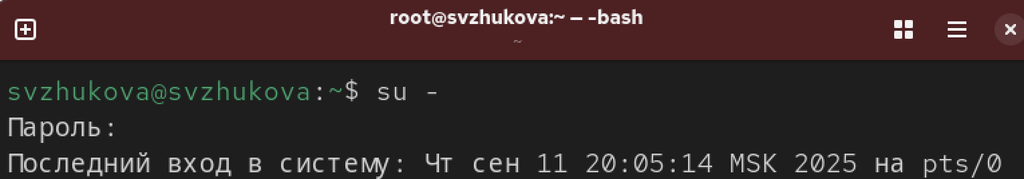

Pоль супер-пользователя

## В корневом каталоге создадим каталоги /data/main и /data/third

Посмотрим, кто является владельцем этих каталогов.

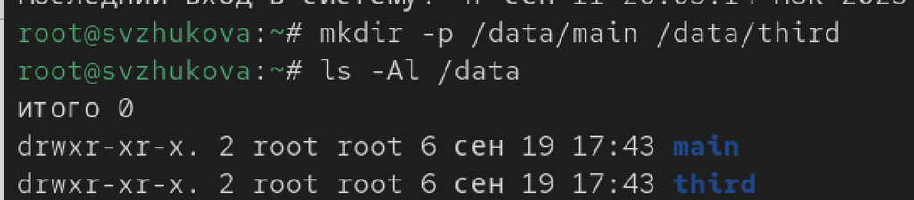

каталоги /data/main и /data/third

Посмотрим, кто теперь является владельцем этих каталогов

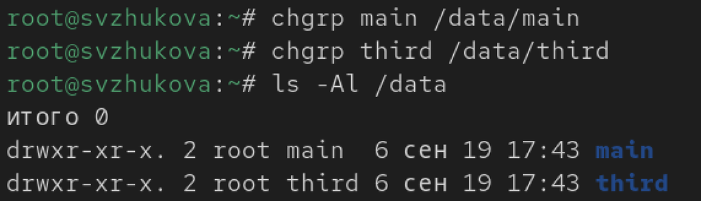

## Установим разрешения, позволяющие владельцам каталогов записывать файлы в эти

каталоги и запрещающие доступ к содержимому каталогов всем другим пользователям и группам Проверим установленные права доступа

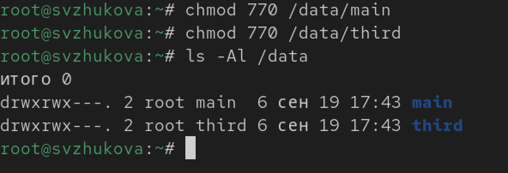

Права доступа

## В другом терминале перейдем под учётную запись пользователя bob

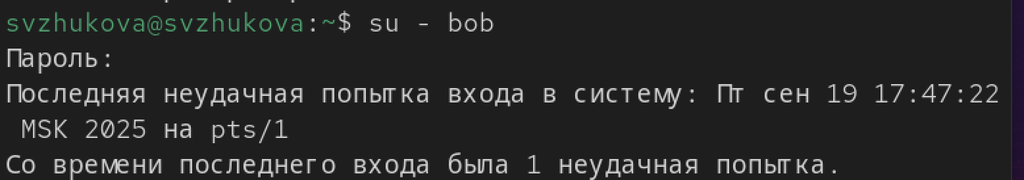

Учётная запись пользователя bob

Под пользователем bob попробуем перейти в каталог /data/main и создать файл emptyfile в этом каталоге

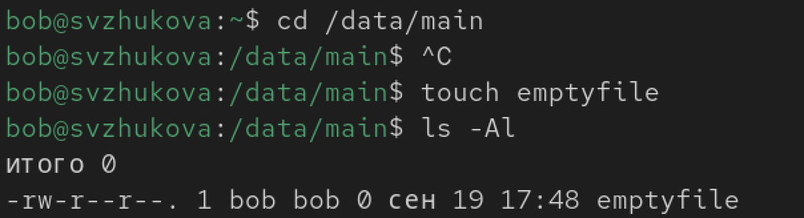

emptyfile

## Под пользователем bob попробуем перейти в каталог /data/third и создать файл emptyfile в этом каталоге

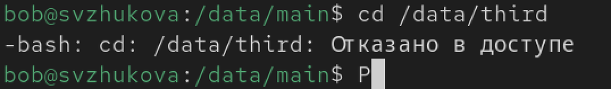

Нам отказано в доступе, нет нужных прав

# Управление специальными разрешениями

Откроем новый терминал под пользователем alice

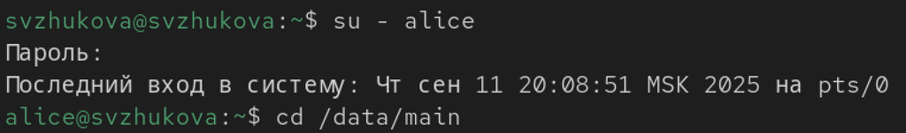

alice

Перейдите в каталог /data/main и создадим два файла, владельцем которых является alice

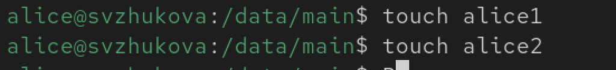

Создадим два файла

## В другом терминале перейдем под учётную запись пользователя bob (пользователь bob является членом группы main, как и alice)

Перейдем в каталог /data/main и в этом каталоге введем

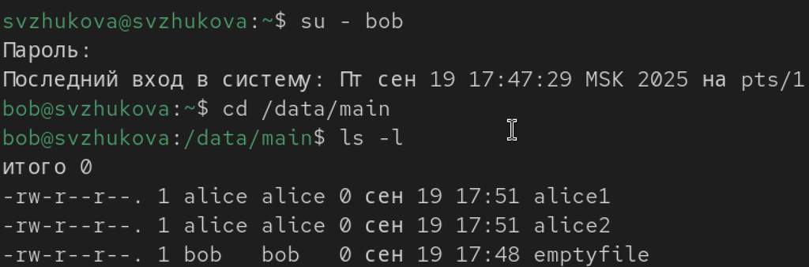

Мы видим два файла, созданные пользователем alice

## Попробуем удалить файлы, принадлежащие пользователю alice

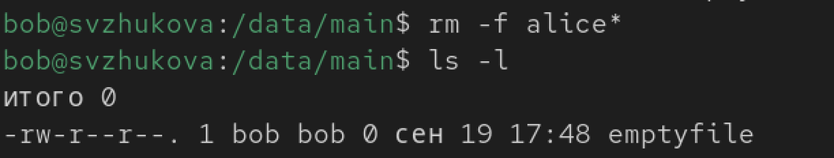

Файлы удалены

## Создадим два файла, которые принадлежат пользователю bob

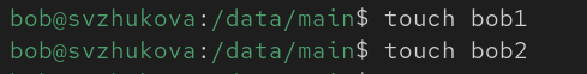

Два файла, которые принадлежат пользователю bob

## В терминале под пользователем root установим для каталога /data/main бит идентификатора группы, а также stiky-бит для разделяемого (общего) каталога группы

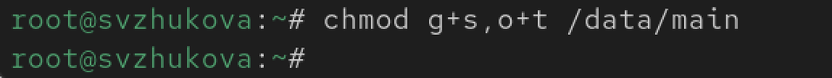

установим идентификатор группы, а также stiky-бит для разделяемого каталога группы

## В терминале под пользователем alice создадим в каталоге /data/main файлы alice3 и alice4

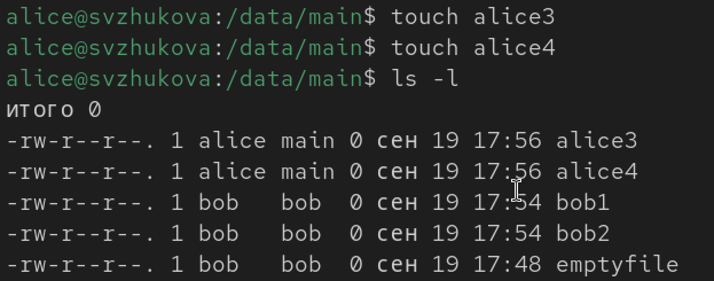

Файлы alice3 и alice4

Теперь мы видим, что два созданных нами файла принадлежат группе main, которая является группой-владельцем каталога /data/main

## В терминале под пользователем alice попробуем удалить файлы, принадлежащие пользователю bob

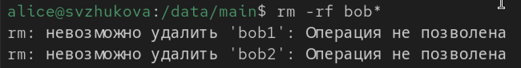

Операция недоступна

# Управление расширенными разрешениями с использованием списков ACL

Откроем терминал с учётной записью root Установим права на чтение и выполнение в каталоге /data/main для группы third и права на чтение и выполнение для группы main в каталоге /data/third:

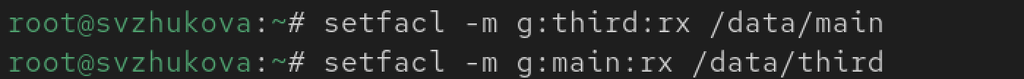

права на чтение и выполнение

## Используем команду getfacl, чтобы убедиться в правильности установки разрешений

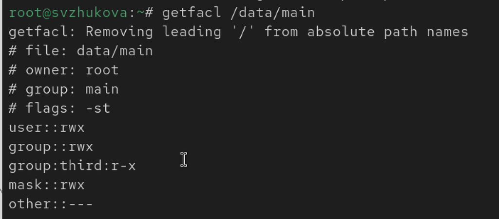

Правильность установки разрешений

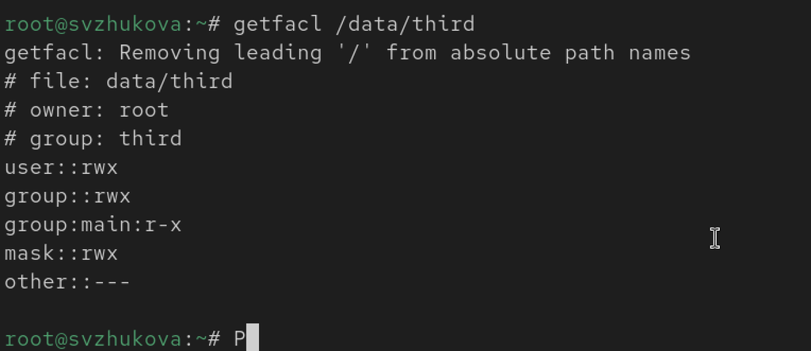

Правильность установки разрешени

Проверим текущие назначения полномочий.

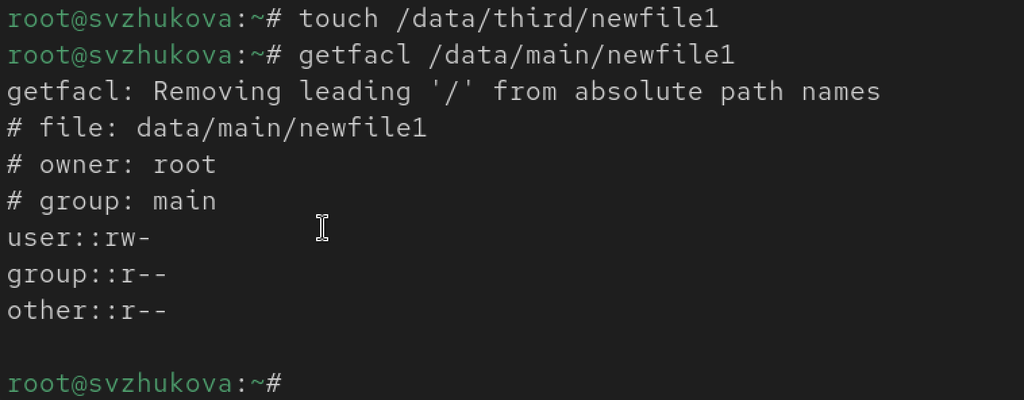

Установим и проверим

## Установим ACL по умолчанию для каталога /data/main:

Добавим ACL по умолчанию для каталога /data/third

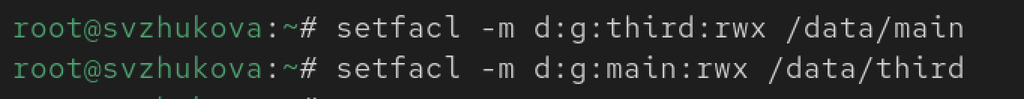

Добавим

## Убедимся, что настройки ACL работают, добавив новый файл в каталог /data/main:

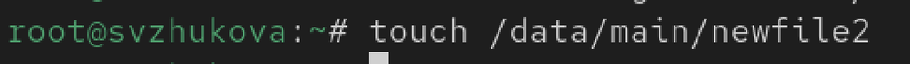

Добавим новый файл в каталог

## Проверим текущие назначения полномочий.

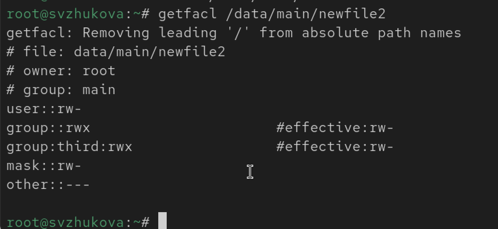

Проверим

## Выполним аналогичные действия для каталога /data/third.

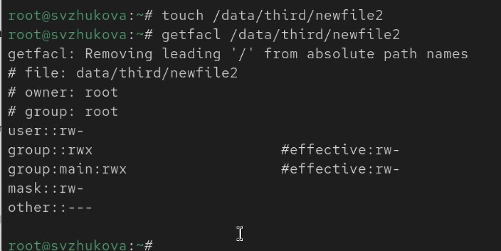

Выполним

Проверим операции с файлами

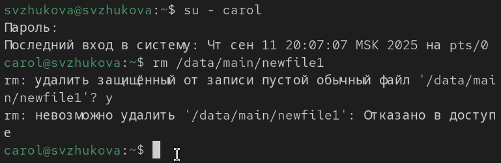

Нельзя

## Проверим, возможно ли осуществить запись в файл

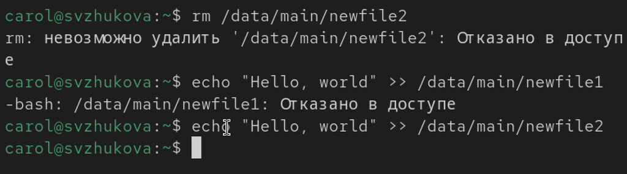

Можно только во втором случае

## Заключение

Мы получили навыки настройки базовых и специальных прав доступа для групп пользователей в операционной системе типа Linux.